# Hierarchical Models or Mixed Models

Amanda Franklin

04/04/2022

## Introduction

This code conducts a generalised linear mixed model, or a hierarchical model following recommendations in Zuur et al. 2009, Mixed Effects Models and Extensions in Ecology with R.

Zuur recommends the following “cookbook” approach 1. Start with a model with all random and all fixed effects 2. Use LRT/AIC/BIC to decide which random effects to keep 3. Re-run winning model with REML = F (i.e. use ML rather than REML) 4. Use marginal hypothesis tests to evaluate fixed effects

If you want to know why all these steps, read Chapter 5 in Zuur

## Libraries

```r
library(lme4) # lmer()
library(tidyverse) # data processing functions and piping
library(bbmle) # ICtabs()
library(car) # Anova()
```

## 1. Dataset information

Grasshopper example

LocMax is the maximum calling frequency (Hz)

```r
dat_gh <- read.csv("../dat/HierarchicalModelsMixedModels.csv")
head(dat_gh)
```

```
##   Site     Individual       Origin Treatment LocMax BodyMass
## 1 Asch AS_lei_la_0001 non-roadside     noisy   7193    0.084
## 2 Asch AS_lei_la_0001 non-roadside     noisy   7239    0.084
## 3 Asch AS_lei_la_0001 non-roadside     noisy   7358    0.084
## 4 Asch AS_Lei_la_0002 non-roadside     noisy   8958    0.086
## 5 Asch AS_Lei_la_0002 non-roadside     noisy   8452    0.086
## 6 Asch AS_Lei_la_0002 non-roadside     noisy   8958    0.086
```

## 2. Look at Variation

This section explains the hierarchical nature of the dataset and demonstrates the sources of variation in the dataset. You may skip this section if you understand this.

First let’s keep it simple and look at controls (quiet, non-roadside) Where is the variation? We have: 1. Variation among populations 2. Variation among individuals 3. Variation among songs within individuals

We can look at the variation at each level Select controls only

```r
dat_gh1 <- dat_gh %>%
  filter(Origin == "non-roadside",
         Treatment == "quiet")
```

#### Observed variance within individuals

```r
varSvec <-  tapply(dat_gh1$LocMax, dat_gh1$Individual, var, na.rm = T) # vector of variances among songs within individuals
varS <-  mean(varSvec, na.rm = T)
varS
```

```
## [1] 59004.4
```

#### Observed variance among individual average values

```r
meanInd <- tapply(dat_gh1$LocMax, dat_gh1$Individual, mean, na.rm = T) # means for each individual
pops <- substr(names(meanInd), start = 1, stop = 2) # identifier for individuals by population
varIvec <- tapply(meanInd, pops, var, na.rm = T) # vector of variances among individual means
varI <- mean(varIvec, na.rm = T)
varI
```

```
## [1] 363785.3
```

#### Observed variance among population average values

```r
meanPop <-  tapply(meanInd, pops, mean, na.rm = T) # means for each individual
varP <-  var(meanPop)
varP
```

```
## [1] 50970.18
```

## 3. Run GLMM

Let’s run a GLMM following the Zuur guidelines

Does inclusion of random effects change our conclusions about effects of noise on songs?

#### Model with no random effects

```r
m1a <-  glm(LocMax ~ Origin*Treatment, data = dat_gh)
Anova(m1a)
```

```
## Analysis of Deviance Table (Type II tests)
##
## Response: LocMax
##                  LR Chisq Df Pr(>Chisq)
## Origin            21.7862  1  3.048e-06 ***
## Treatment         11.4343  1   0.000721 ***
## Origin:Treatment   0.5008  1   0.479145
## ---
## Signif. codes:  0 '***' 0.001 '**' 0.01 '*' 0.05 '.' 0.1 ' ' 1
```

#### Full model (i.e. Zuur step 1)

```r
m1b <- lmer(LocMax ~ Origin*Treatment + (1|Individual) + (1|Site),
            data = dat_gh)
Anova(m1b)
```

```
## Analysis of Deviance Table (Type II Wald chisquare tests)
##
## Response: LocMax
##                   Chisq Df Pr(>Chisq)
## Origin           4.5793  1    0.03236 *
## Treatment        4.2083  1    0.04023 *
## Origin:Treatment 0.1972  1    0.65697
## ---
## Signif. codes:  0 '***' 0.001 '**' 0.01 '*' 0.05 '.' 0.1 ' ' 1
```

Note: the p-values are quite different, the random effects can have a substantial influence on the p-values (usually increasing)

#### Look at the output:

```r
summary(m1b)
```

```
## Linear mixed model fit by REML ['lmerMod']
## Formula: LocMax ~ Origin * Treatment + (1 | Individual) + (1 | Site)
##    Data: dat_gh
##
## REML criterion at convergence: 7992.5
##
## Scaled residuals:
##     Min      1Q  Median      3Q     Max
## -3.8381 -0.3849 -0.0576  0.3395  3.7530
##
## Random effects:
##  Groups     Name        Variance Std.Dev.
##  Individual (Intercept) 705159   839.7
##  Site       (Intercept)  34705   186.3
##  Residual                97025   311.5
## Number of obs: 523, groups:  Individual, 177; Site, 9
##
## Fixed effects:
##                               Estimate Std. Error t value
## (Intercept)                     7233.3      171.3  42.222
## Originroadside                   382.3      199.1   1.920
## Treatmentquiet                  -191.8      214.2  -0.896
## Originroadside:Treatmentquiet   -120.0      270.2  -0.444
##
## Correlation of Fixed Effects:
##             (Intr) Orgnrd Trtmnt
## Originrodsd -0.765
## Treatmentqt -0.633  0.538
## Orgnrdsd:Tr  0.500 -0.646 -0.794
```

Random effect section shows the variation among individuals, sites and among songs within individuals (residual)

#### What random effects should we include? (Zuur Step 2)

We can use likelihood ratio tests, AIC or BIC to decide. Here we use AIC.

```r
m2a <- glm(LocMax ~ Origin*Treatment, data = dat_gh)
m2b <- lmer(LocMax ~ Origin*Treatment + (1|Individual) + (1|Site),
            data = dat_gh)
m2c <- lmer(LocMax ~ Origin*Treatment + (1|Individual), data = dat_gh)
m2d <- lmer(LocMax ~ Origin*Treatment + (1|Site), data = dat_gh)

ICtab(m2a, m2b, m2c, m2d)
```

```
##     dAIC  df
## m2c   0.0 6
## m2b   0.0 7
## m2d 536.8 6
## m2a 594.9 5
```

This indicates c and b are best. Since c and b are similar, and d is worse, site doesn’t really improve the fit. Only Individual needs to be included as a random effect

#### Run best model but using ML (i.e. REML = F, Zuur Step 3)

```r
m2c.1 <- lmer(LocMax ~ Origin*Treatment + (1|Individual),
              data = dat_gh, REML = F)
```

#### Use marginal hypothesis tests to evaluate fixed effects (Zuur step 4)

```r
Anova(m2c.1)
```

```
## Analysis of Deviance Table (Type II Wald chisquare tests)
##
## Response: LocMax
##                   Chisq Df Pr(>Chisq)
## Origin           8.0878  1   0.004456 **
## Treatment        4.0382  1   0.044480 *
## Origin:Treatment 0.1334  1   0.714912
## ---
## Signif. codes:  0 '***' 0.001 '**' 0.01 '*' 0.05 '.' 0.1 ' ' 1
```

```r
Anova(m2c)
```

```
## Analysis of Deviance Table (Type II Wald chisquare tests)
##
## Response: LocMax
##                   Chisq Df Pr(>Chisq)
## Origin           7.9053  1   0.004929 **
## Treatment        3.9468  1   0.046962 *
## Origin:Treatment 0.1303  1   0.718090
## ---
## Signif. codes:  0 '***' 0.001 '**' 0.01 '*' 0.05 '.' 0.1 ' ' 1
```

Results are similar for ML and REML Strong evidence for effect of Origin, less for effect of Treatment

## 4. Plot

#### Create model to get MLEs for plotting

```r
m2c.2 <- lmer(LocMax ~ -1 + Origin:Treatment + (1|Individual),
              data = dat_gh, REML = F)
summary(m2c.2)
```

```
## Linear mixed model fit by maximum likelihood  ['lmerMod']
## Formula: LocMax ~ -1 + Origin:Treatment + (1 | Individual)
##    Data: dat_gh
##
##      AIC      BIC   logLik deviance df.resid
##   8053.0   8078.6  -4020.5   8041.0      517
##
## Scaled residuals:
##     Min      1Q  Median      3Q     Max
## -3.8234 -0.3863 -0.0558  0.3328  3.7679
##
## Random effects:
##  Groups     Name        Variance Std.Dev.
##  Individual (Intercept) 716881   846.7
##  Residual                97035   311.5
## Number of obs: 523, groups:  Individual, 177
##
## Fixed effects:
##                                   Estimate Std. Error t value
## Originnon-roadside:Treatmentnoisy   7176.7      153.3   46.80
## Originroadside:Treatmentnoisy       7609.8      110.9   68.61
## Originnon-roadside:Treatmentquiet   6976.7      150.8   46.27
## Originroadside:Treatmentquiet       7310.9      121.3   60.27
##
## Correlation of Fixed Effects:
##                     Orgnnn-rdsd:Trtmntn Orgnrdsd:Trtmntn Orgnnn-rdsd:Trtmntq
## Orgnrdsd:Trtmntn    0.000
## Orgnnn-rdsd:Trtmntq 0.000               0.000
## Orgnrdsd:Trtmntq    0.000               0.000            0.000
```

```r
LocMax <- fixef(m2c.2)
group.CIs <- confint(m2c.2)[3:6,]
```

```
## Computing profile confidence intervals ...
```

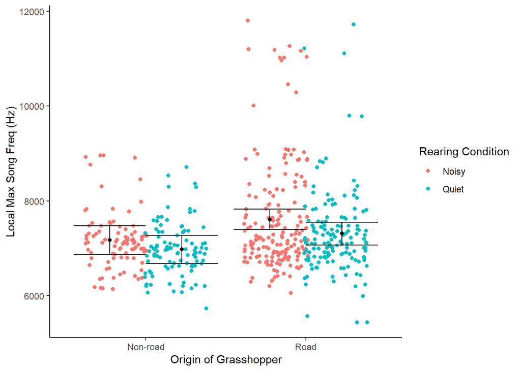

```r
colnames(group.CIs) <- c("lower", "upper")
Origin <- c("Non-road", "Road", "Non-road", "Road")
`Rearing Condition` <- c("Noisy", "Noisy", "Quiet", "Quiet")
dat_plot <- data.frame(Origin, `Rearing Condition`, LocMax, group.CIs)

# If you want, you can also plot the raw data
# We'll make some changes so the datasets match
dat_gh2 <- dat_gh %>%
  mutate(Origin = ifelse(Origin == "roadside", "Road", "Non-road"),
         Treatment = ifelse(Treatment == "noisy", "Noisy", "Quiet")) %>%
  dplyr::rename(`Rearing Condition` = Treatment)

plot1 <- ggplot(dat_gh2, aes(x = Origin, y = LocMax,
                             group = `Rearing Condition`)) +
  geom_point(aes(colour = `Rearing Condition`),
             position = position_jitterdodge()) +
  geom_point(data = dat_plot, aes(x = Origin, y = LocMax),
             position = position_dodge(width = 0.9), colour = "black") +
  geom_errorbar(data = dat_plot, aes(ymin = lower, ymax = upper),
                position = position_dodge(width = 0.9)) +
  theme_classic() +
  ylab("Local Max Song Freq (Hz)") + xlab("Origin of Grasshopper")
plot1
```